# Predicting Drug Use Risk by Personality and Recency

McCray, Victoria

Spring 2025

## Business Understanding

The paper The Five Factor Model of personality and evaluation of drug consumption risk by [Fehrman et al. 2015](https://arxiv.org/abs/1506.06297).

For my project, I am using the Drug Consumption (Quantified) dataset from the UCI Machine Learning Repository. This dataset contains 1,885 observations and 32 numerical features, including self-reported personality traits, demographics, and substance use history across multiple drugs.

My goal is to develop a continuous risk score for substance use by predicting the recency of drug use using regression. The dataset classifies drug use in ordinal categories (CL0 to CL6), where higher values indicate more recent use. I will convert this into a numerical risk score and explore weighting based on drug severity and co-usage correlations.

I plan to implement an ensemble regression model, using:

Random Forest Regression to capture non-linear relationships. Gradient Boosting Regression (GBR) for improved predictive performance. Since the dataset is fully numeric, no categorical encoding is needed. However, I will ordinally encode the recency variable and apply scaling (Min-Max or Z-score) to standardize features. To test model robustness, I will simulate missing values (<5%) and handle them accordingly. For >5% missing values, I may use mean or median imputation instead of removal.

The dataset’s sample size (1,885 observations) should provide enough statistical power for the regression models. Additionally, I will explore using cross-validation (e.g., k-fold cross-validation) to assess model performance, considering the ensemble approach.

Model performance will be evaluated using R-squared, RMSE, and MAE. While prior research has used this dataset for classification, few studies have predicted a continuous risk score based on recency of drug use. My approach introduces a novel perspective by shifting from classification to regression.

[Drug Consumption (Quantified) - UCI ML Repository](https://archive.ics.uci.edu/dataset/373/drug+consumption+quantified)

References

Fehrman, E., Muhammad, A. K., Mirkes, E. M., Egan, V., & Gorban, A. N. (2017). The five factor model of personality and evaluation of drug consumption risk. In Data science: innovative developments in data analysis and clustering (pp. 231-242). Springer International Publishing. https://arxiv.org/abs/1506.06297

## Data Understanding

Each drug (like alcohol, cannabis, heroin, etc.) has its own column, with values from:

- CL0: Never used
- CL1: Used over a decade ago
- CL2: Used in last decade
- CL3: Used in last year
- CL4: Used in last month
- CL5: Used in last week
- CL6: Used in last day

These ordinal values reflect recency and frequency of use.

```r
# install packages if needed before loading
#install.packages("gridExtra")
#install.packages("h2o")
#install.packages("xgboost")
#install.packages("caretEnsemble")
```

```r
# Load necessary libraries
library(caret)       # For modeling & evaluation
library(randomForest) # Random Forest Regression
library(gbm)         # Gradient Boosting Regression
library(car)         # For VIF (multicollinearity check)
```

```r
library(ggplot2)  # data visualization
library(psych)  # for correlation matrix and visualization
library(gridExtra) # output formatting
library(h2o)         # performing dimension reduction
library(xgboost)         # gradient boost for ensemble models
library(caretEnsemble) # ensemble methods
```

```r
url <- "https://archive.ics.uci.edu/static/public/373/data.csv"

df <- read.csv(url, header = TRUE)
prime_df <- df # make a copy of the original dataset
```

```r
# Preliminary data exploration
str(df)       # Check structure
```

```
## 'data.frame':    1885 obs. of  32 variables:
##  $ id       : int  1 2 3 4 5 6 7 8 9 10 ...
##  $ age      : num  0.4979 -0.0785 0.4979 -0.952 0.4979 ...
##  $ gender   : num  0.482 -0.482 -0.482 0.482 0.482 ...
##  $ education: num  -0.0592 1.9844 -0.0592 1.1637 1.9844 ...
##  $ country  : num  0.961 0.961 0.961 0.961 0.961 ...
##  $ ethnicity: num  0.126 -0.317 -0.317 -0.317 -0.317 ...
##  $ nscore   : num  0.313 -0.678 -0.467 -0.149 0.735 ...
##  $ escore   : num  -0.575 1.939 0.805 -0.806 -1.633 ...
##  $ oscore   : num  -0.5833 1.4353 -0.8473 -0.0193 -0.4517 ...
##  $ ascore   : num  -0.917 0.761 -1.621 0.59 -0.302 ...
##  $ cscore   : num  -0.00665 -0.14277 -1.0145 0.58489 1.30612 ...
##  $ impuslive: num  -0.217 -0.711 -1.38 -1.38 -0.217 ...
##  $ ss       : num  -1.181 -0.216 0.401 -1.181 -0.216 ...
##  $ alcohol  : chr  "CL5" "CL5" "CL6" "CL4" ...
```

[output cut: 18 more lines]

```r
summary(df)   # Summary statistics
```

```
##        id              age               gender             education
##  Min.   :   1.0   Min.   :-0.95197   Min.   :-0.4824600   Min.   :-2.435910
##  1st Qu.: 474.0   1st Qu.:-0.95197   1st Qu.:-0.4824600   1st Qu.:-0.611130
##  Median : 946.0   Median :-0.07854   Median :-0.4824600   Median :-0.059210
##  Mean   : 945.3   Mean   : 0.03461   Mean   :-0.0002559   Mean   :-0.003806
##  3rd Qu.:1417.0   3rd Qu.: 0.49788   3rd Qu.: 0.4824600   3rd Qu.: 0.454680
##  Max.   :1888.0   Max.   : 2.59171   Max.   : 0.4824600   Max.   : 1.984370
##     country          ethnicity           nscore              escore
##  Min.   :-0.5701   Min.   :-1.1070   Min.   :-3.464360   Min.   :-3.273930
##  1st Qu.:-0.5701   1st Qu.:-0.3169   1st Qu.:-0.678250   1st Qu.:-0.695090
##  Median : 0.9608   Median :-0.3169   Median : 0.042570   Median : 0.003320
##  Mean   : 0.3555   Mean   :-0.3096   Mean   : 0.000047   Mean   :-0.000163
##  3rd Qu.: 0.9608   3rd Qu.:-0.3169   3rd Qu.: 0.629670   3rd Qu.: 0.637790
##  Max.   : 0.9608   Max.   : 1.9072   Max.   : 3.273930   Max.   : 3.273930
##      oscore              ascore              cscore
##  Min.   :-3.273930   Min.   :-3.464360   Min.   :-3.464360
##  1st Qu.:-0.717270   1st Qu.:-0.606330   1st Qu.:-0.652530
##  Median :-0.019280   Median :-0.017290   Median :-0.006650
##  Mean   :-0.000534   Mean   :-0.000245   Mean   :-0.000386
##  3rd Qu.: 0.723300   3rd Qu.: 0.760960   3rd Qu.: 0.584890
##  Max.   : 2.901610   Max.   : 3.464360   Max.   : 3.464360
##    impuslive               ss              alcohol             amphet
##  Min.   :-2.555240   Min.   :-2.078480   Length:1885        Length:1885
##  1st Qu.:-0.711260   1st Qu.:-0.525930   Class :character   Class :character
##  Median :-0.217120   Median : 0.079870   Mode  :character   Mode  :character
##  Mean   : 0.007216   Mean   :-0.003292
##  3rd Qu.: 0.529750   3rd Qu.: 0.765400
##  Max.   : 2.901610   Max.   : 1.921730
##      amyl              benzos              caff             cannabis
##  Length:1885        Length:1885        Length:1885        Length:1885
##  Class :character   Class :character   Class :character   Class :character
##  Mode  :character   Mode  :character   Mode  :character   Mode  :character
##
##
##
##      choc               coke              crack             ecstasy
##  Length:1885        Length:1885        Length:1885        Length:1885
##  Class :character   Class :character   Class :character   Class :character
##  Mode  :character   Mode  :character   Mode  :character   Mode  :character
##
```

[output cut: 8 more lines]

```
##
##      meth            mushrooms           nicotine            semer
##  Length:1885        Length:1885        Length:1885        Length:1885
##  Class :character   Class :character   Class :character   Class :character
##  Mode  :character   Mode  :character   Mode  :character   Mode  :character
##
##
##
##      vsa
##  Length:1885
##  Class :character
##  Mode  :character
##
##
##
```

```r
sum(is.na(df)) # Check for missing values
```

```
## [1] 0
```

I have conducted preliminary analysis in R, confirming no missing values and identifying skewness in age and ethnic representation (78% age 18-44 and 91.25% White).

### Visualize Distributions

For my inspection of the feature distributions, I am looking for the following:

- Detect skewness and outliers that might impact model assumptions and performance. For example, drug usage variables often exhibit right skew due to many participants reporting non-use.
- Assess the approximate normality of personality and demographic features, which may inform the choice of scaling techniques (e.g., Z-score normalization vs. Min-Max scaling).

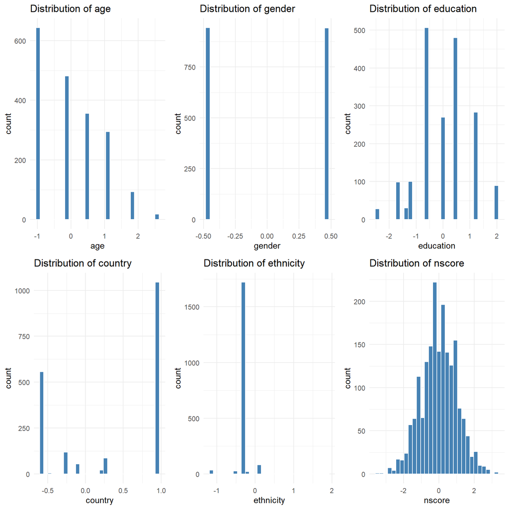

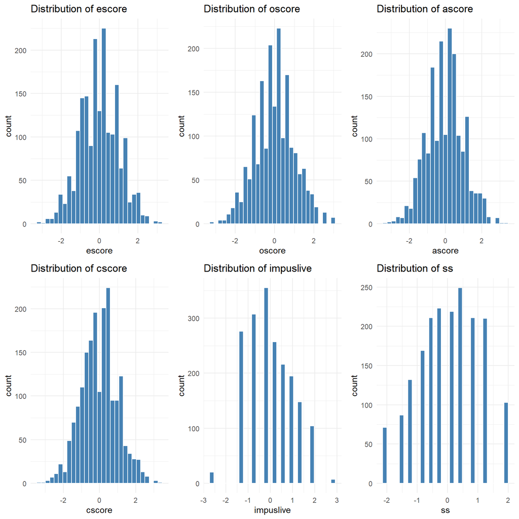

```r
# Check the distribution for columns that are numeric, excluding "id"
numeric_vars <- setdiff(names(df)[sapply(df, is.numeric)], "id")

### grid formatting adapted from https://cran.r-project.org/web/packages/egg/vignettes/Ecosystem.html

# Create a list of ggplot objects
plot_list <- lapply(numeric_vars, function(col) {
  ggplot(df, aes_string(x = col)) +
    geom_histogram(bins = 30, fill = "steelblue", color = "white") +
    theme_minimal() +
    ggtitle(paste("Distribution of", col))
})

# Number of plots per page (adjust based on your PDF/page size)
plots_per_page <- 6
pages <- split(plot_list, ceiling(seq_along(plot_list) / plots_per_page))

# Display plots in a grid, 2 columns by 3 rows per page
for (page in pages) {
  do.call(grid.arrange, c(page, ncol = 3, nrow = 2))
}
```

### Identify Outliers

Boxplots are visualizations used to identify outliers by showing the spread of the data, and data points outside the interquartile ranged are potential outliers. Because regression is sensitive to outliers, these are inspected.

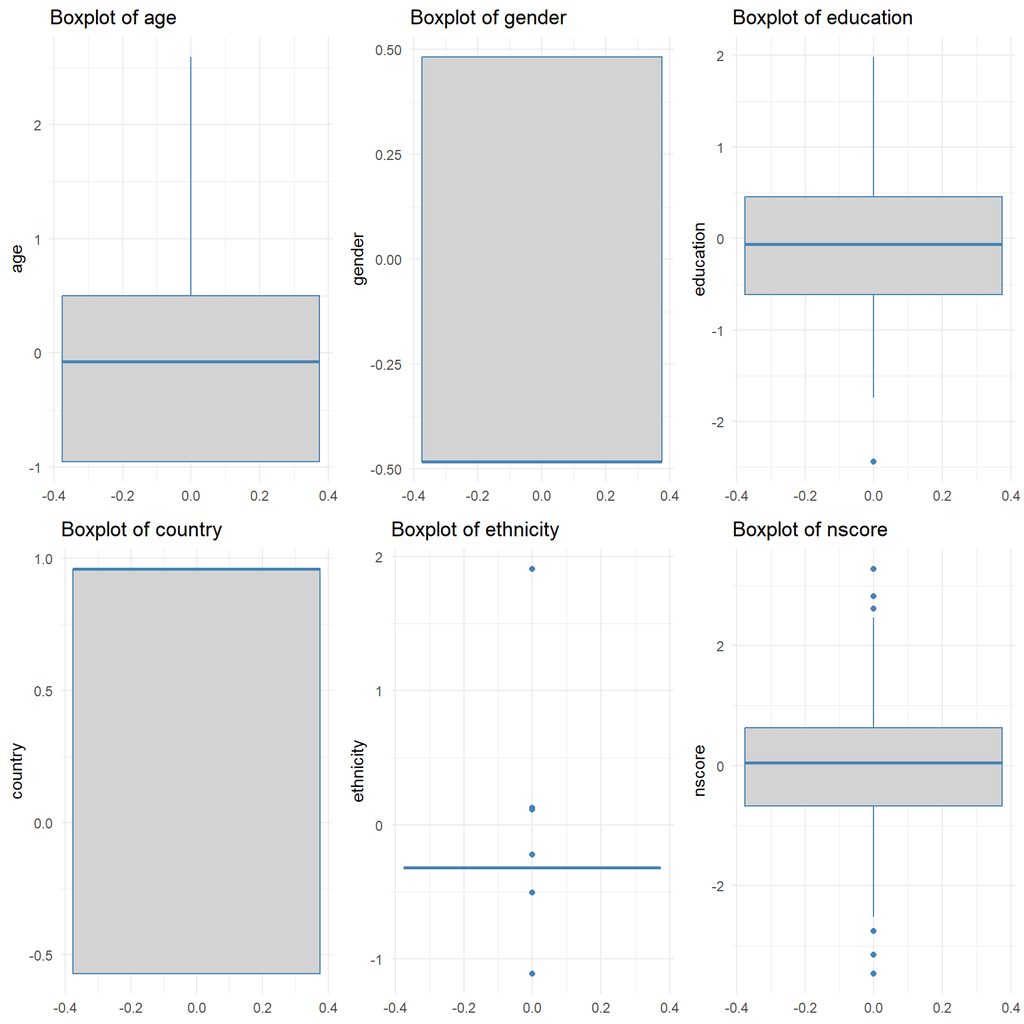

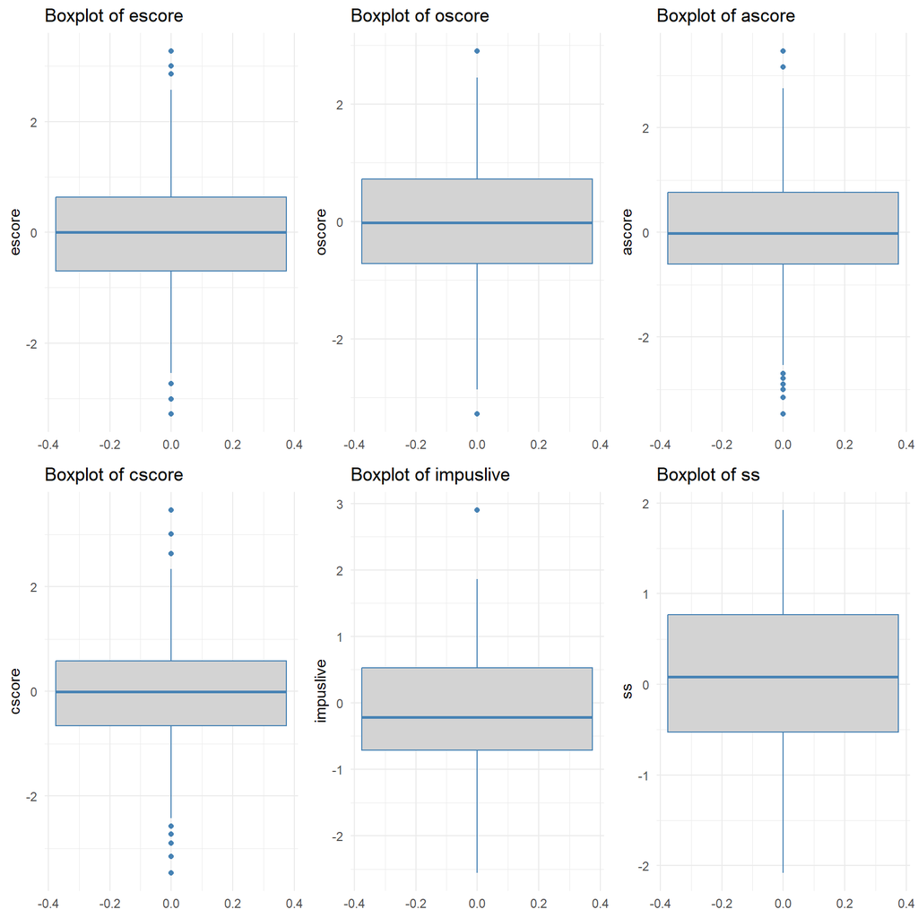

```r
# Check for columns that are numeric, excluding "id"
numeric_vars <- setdiff(names(df)[sapply(df, is.numeric)], "id")

### grid formatting adapted from https://cran.r-project.org/web/packages/egg/vignettes/Ecosystem.html

# Create a list of ggplot objects for boxplots
plot_list <- lapply(numeric_vars, function(col) {
  ggplot(df, aes_string(y = col)) +
    geom_boxplot(fill = "lightgrey", color = "steelblue") +
    theme_minimal() +
    ggtitle(paste("Boxplot of", col)) +
    theme(axis.title.x = element_blank()) # Remove x-axis label for cleaner plot
})

# Number of plots per page (adjust based on your PDF/page size)
plots_per_page <- 6
pages <- split(plot_list, ceiling(seq_along(plot_list) / plots_per_page))

# Display plots in a grid, 2 columns by 3 rows per page
for (page in pages) {
  do.call(grid.arrange, c(page, ncol = 3, nrow = 2))
}
```

The loop is creating boxplots for each numeric variable in the dataframe. When we observe values like 3 or -3, those are possible outliers (values more than ~3 standard deviations from the mean).

Some personality trait variables, such as cscore, ascore, and oscore, show values approaching or exceeding ±3, which suggests the presence of a few extreme responders. These scores represent individuals who are several standard deviations away from the mean, indicating unusually high or low levels of the trait.

### Simulate Missing Data

The simulated approach introduces null values to cells. It is agnostic to column type or names. However, it can also introduce null values to non-numeric columns.

This approach samples across the entire dataset, including character or factor columns. If needed, one can filter only numeric columns before sampling to simulate Missing Completely at Random (MCAR) in a more controlled way. MCAR indicates the probability of a value being missing is completely unrelated to any observed or unobserved data.

```r
# approach adapted from http://artificium.us/lessons/03.ml/l-3-204-missing-values/l-3-204.html

set.seed(123)  # for reproducibility

# Make a copy so original is preserved
sim_data <- df

# Get total number of cells
total_cells <- prod(dim(sim_data))

# Calculate how many to make NA
missing_rate <- 0.05
n_missing <- floor(missing_rate * total_cells)

# Sample from all cells in row-major order
missing_positions <- sample(total_cells, n_missing, replace = FALSE)

# Convert to (row, col) index positions
missing_indices <- arrayInd(missing_positions, .dim = dim(sim_data))

# Set each selected cell to NA
for (i in seq_len(n_missing)) {
  sim_data[missing_indices[i, 1], missing_indices[i, 2]] <- NA
}

# Option to restrict to numeric columns if needed
numeric_idx <- which(sapply(sim_data, is.numeric))
selected_positions <- arrayInd(sample(prod(dim(sim_data[, numeric_idx])), n_missing), .dim = dim(sim_data[, numeric_idx]))

# reassign to df label
df <- sim_data
```

### Correlation Analysis

```r
# capture all the features related to drug use and the chocolate control field
drug_features <- c("alcohol","amphet","amyl","benzos","caff","cannabis","choc","coke","crack","ecstasy","heroin","ketamine","legalh","lsd","meth","mushrooms","nicotine")
```

### Ordinal Encoding

Ordinal encoding is one of the most important steps for this algorithm because it applies the mappings of recency/frequency for drug usage to all the drug features.

Ordinal encoding is helpful before conducting the correlational analysis.

```r
# list drug usage features
drug_features <- c("alcohol","amphet","amyl","benzos","caff","cannabis","choc","coke","crack","ecstasy","heroin","ketamine","legalh","lsd","meth","mushrooms","nicotine")

# apply as numerical factor to each of the categories
for (drug in drug_features) {
  df[[drug]] <- as.numeric(factor(df[[drug]], levels = c("CL0", "CL1", "CL2", "CL3", "CL4", "CL5", "CL6")))
}

head(df)
```

|  | id | age | gender | education | country | ethnicity | nscore | escore | oscore | ascore | cscore | impuslive | ss | alcohol | amphet | amyl | benzos | caff | cannabis | choc | coke | crack | ecstasy | heroin | ketamine | legalh | lsd | meth | mushrooms | … |
| --- | --- | --- | --- | --- | --- | --- | --- | --- | --- | --- | --- | --- | --- | --- | --- | --- | --- | --- | --- | --- | --- | --- | --- | --- | --- | --- | --- | --- | --- | --- |
| 1 | 1 | 0.49788 | 0.48246 | -0.05921 | 0.96082 | 0.12600 | 0.31287 | -0.57545 | -0.58331 | -0.91699 | -0.00665 | -0.21712 | -1.18084 | 6 | 3 | NA | 3 | 7 | 1 | 6 | 1 | 1 | 1 | 1 | 1 | 1 | 1 | 1 | 1 | … |
| 2 | 2 | -0.07854 | -0.48246 | 1.98437 | 0.96082 | -0.31685 | -0.67825 | 1.93886 | 1.43533 | 0.76096 | -0.14277 | -0.71126 | -0.21575 | 6 | 3 | 3 | 1 | 7 | 5 | NA | 4 | NA | 5 | 1 | 3 | 1 | 3 | 4 | 1 | … |
| 3 | 3 | 0.49788 | -0.48246 | -0.05921 | 0.96082 | -0.31685 | -0.46725 | 0.80523 | -0.84732 | -1.62090 | -1.01450 | -1.37983 | 0.40148 | 7 | 1 | 1 | 1 | 7 | 4 | 5 | 1 | 1 | 1 | 1 | 1 | 1 | 1 | 1 | 2 | … |
| 4 | 4 | -0.95197 | 0.48246 | 1.16365 | 0.96082 | -0.31685 | -0.14882 | -0.80615 | -0.01928 | 0.59042 | 0.58489 | -1.37983 | -1.18084 | 5 | 1 | 1 | 4 | 6 | 3 | 5 | 3 | 1 | 1 | 1 | 3 | 1 | 1 | 1 | 1 | … |
| 5 | NA | 0.49788 | 0.48246 | 1.98437 | 0.96082 | -0.31685 | 0.73545 | -1.63340 | -0.45174 | -0.30172 | 1.30612 | -0.21712 | -0.21575 | 5 | 2 | 2 | 1 | 7 | 4 | 7 | 1 | 1 | 2 | 1 | 1 | 2 | 1 | 1 | 3 | … |
| 6 | 6 | 2.59171 | 0.48246 | -1.22751 | 0.24923 | -0.31685 | -0.67825 | NA | -1.55521 | 2.03972 | 1.63088 | -1.37983 | -1.54858 | 3 | 1 | 1 | 1 | 7 | 1 | 5 | 1 | 1 | 1 | 1 | 1 | 1 | 1 | 1 | 1 | … |

```r
# Subset personality traits and drug use
personality_vars <- c("nscore", "escore", "oscore", "ascore", "cscore")
personality_vars_df <- df[, personality_vars]

drug_vars_df <- df[, drug_features]

# Combine for correlation
corr_data <- cbind(personality_vars_df, drug_vars_df)

# Compute correlation matrix with significance
cor_results <- corr.test(corr_data)
```

The algorithm ran a correlation matrix between Big Five personality traits and drug use variables.

| Personality Trait | Meaning |
| --- | --- |
| nscore | Neuroticism (emotional instability) |
| escore | Extraversion |
| oscore | Openness to Experience |
| ascore | Agreeableness |
| cscore | Conscientiousness |

```r
# Compute correlation matrix with p-values
cor_results <- corr.test(corr_data)

# Extract correlations and p-values
r <- cor_results$r
p <- cor_results$p

# Get the upper triangle indices (excluding diagonal)
upper_idx <- which(upper.tri(p), arr.ind = TRUE)

# Filter for significant correlations
sig_idx <- upper_idx[p[upper_idx] < 0.05]

# Get variable names
vars <- colnames(p)

# Create result table
sig_results <- data.frame(
  Var1 = vars[upper_idx[, 1]][p[upper_idx] < 0.05],
  Var2 = vars[upper_idx[, 2]][p[upper_idx] < 0.05],
  Correlation = r[upper_idx][p[upper_idx] < 0.05],
  P_value = p[upper_idx][p[upper_idx] < 0.05]
)

# Sort by p-value
sig_results <- sig_results[order(sig_results$P_value), ]

# Show result
print(sig_results)
```

```
##          Var1      Var2 Correlation       P_value
## 142       lsd mushrooms  0.66998164 2.895289e-221
## 62       coke   ecstasy  0.60714907 2.024293e-171
## 135  cannabis mushrooms  0.58342529 1.247242e-153
## 110   ecstasy       lsd  0.56650787 1.206889e-144
## 61   cannabis   ecstasy  0.55931584 3.996296e-140
## 95   cannabis    legalh  0.55630056 4.004647e-136
## 98    ecstasy    legalh  0.55495398 6.885969e-136
## 138   ecstasy mushrooms  0.54124211 1.082308e-128
## 75      crack    heroin  0.54391675 1.268414e-128
## 141    legalh mushrooms  0.53296729 1.365602e-122
## 120    benzos      meth  0.52604097 2.536033e-120
## 107  cannabis       lsd  0.52226121 1.696892e-118
## 39     amphet      coke  0.51991488 8.320646e-116
## 58     amphet   ecstasy  0.51061349 6.446519e-112
```

[output cut: 147 more lines]

The correlation table shows that there are 161 significantly correlated relationships between features, especially where drug usage variables are correlated with one another.

For example, `lsd` and `mushrooms` usage show the most statistically significant and the strongest correlation (at 0.6699816), likely because they are both psychedelics.

Nicotine is more weakly correlated with other variables.

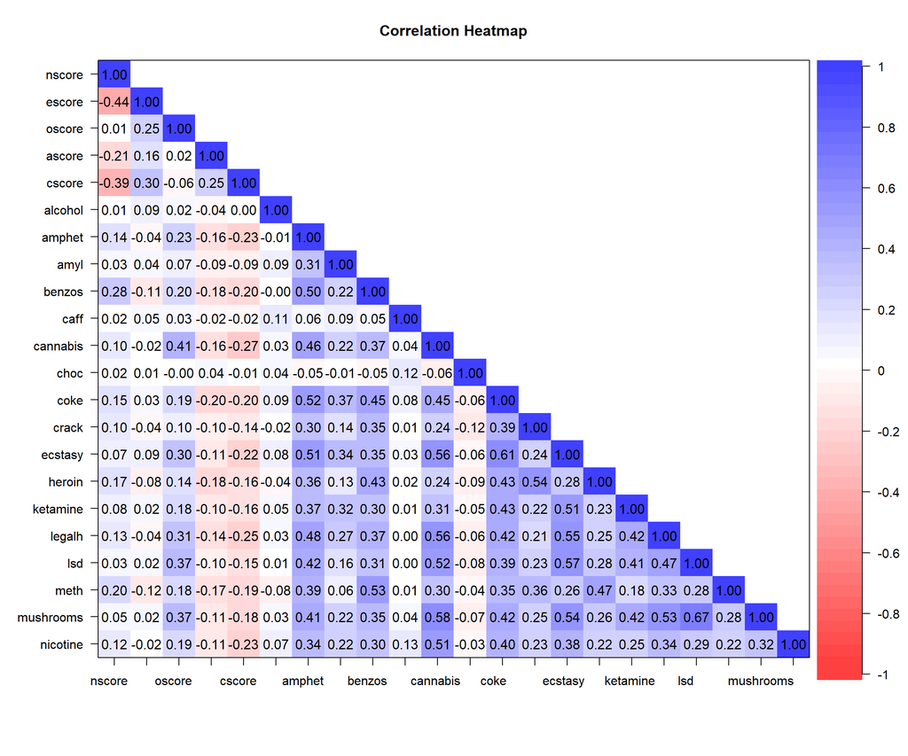

```r
# Get just the correlation matrix from your previous results
corr_matrix <- cor_results$r
# Plot the correlation heatmap
corPlot(cor_results$r,
        numbers = TRUE,   # show correlation coefficients
        upper = FALSE,    # show lower triangle only
        main = "Correlation Heatmap",
        cex = 0.7)        # adjust text size
```

Openness to Experience was consistently associated with increased usage of cannabis, ecstasy, and cocaine. Conversely, Agreeableness and Conscientiousness were negatively associated with multiple substances, particularly nicotine and ecstasy, suggesting protective effects. Interestingly, Neuroticism had a modest positive link with nicotine and cannabis use. Alcohol use showed minimal association with personality traits.

### Multicollinearity Analysis

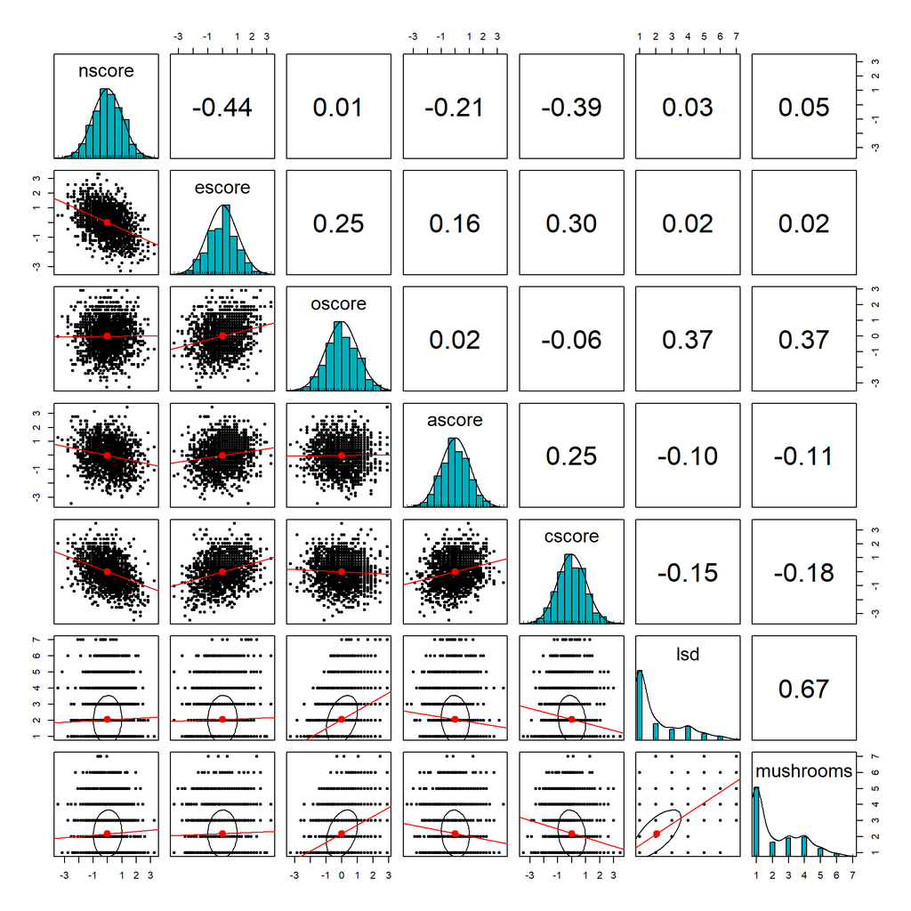

```r
# Select all numeric columns
numeric_vars <- df[, c("age", "gender", "education", "country", "ethnicity",
                       "nscore", "escore", "oscore", "ascore", "cscore",
                       "impuslive", "ss", "alcohol", "amphet", "amyl", "benzos",
                       "caff", "cannabis", "choc", "coke", "crack", "ecstasy",
                       "heroin", "ketamine", "legalh", "lsd", "meth", "mushrooms",
                       "nicotine")]

# filter and refine lists by specific potential relationships

# psychedelic usage and personality variables
psych_personality_vars <- df[, c("nscore", "escore", "oscore", "ascore", "cscore", "lsd", "mushrooms")]


# Generate pairwise panel plot
pairs.panels(psych_personality_vars,
             method = "pearson",   # Correlation method (can be "spearman" or "kendall")
             hist.col = "#00AFBB", # Histogram color
             density = TRUE,       # Add density plot on diagonal
             ellipses = TRUE,      # Confidence ellipses in scatterplots
             lm = TRUE)            # Add regression lines to scatterplots
```

## Data Preparation

Regression Assumptions (for residual analysis & interpretability) Even though ensemble models don’t strictly require them:

- Linearity & Homoscedasticity: Plot residuals vs. predictions
- Normality of errors: QQ-plots or Shapiro-Wilk test on residuals.
- Independence: Inspect for any time-series or other nested structure.

### Create Derived Variables

Multiple composite risk scores were derived to quantify drug use frequency or severity using additive, weighted, and dimensionality-reduced (PCA) approaches.

#### Additive (Sum-Based) Risk Calculation

The first approach calculates the sum of an individual’s usage across the drug features (where a higher count indicates higher risk):

```r
# Create sum-based recency score (higher = more recent/frequent use)
df$risk_score <- rowSums(df[drug_features], na.rm = TRUE)

# view the first values
head(df$risk_score)
```

```
## [1] 38 52 37 41 44 35
```

#### Weighted Risk Calculation

The second approach calculates risk using the severity of the drug to weigh risk:

```r
# Define weights
weights <- c(
  alcohol = 0.5,
  cannabis = 1.0,
  heroin = 3.0,
  coke = 2.5,
  lsd = 1.5,
  ecstasy = 1.8,
  meth = 2.2,
  amphet = 2.0,
  nicotine = 0.8
)

# filter for drug features with weights
selected_drugs <- intersect(drug_features, names(weights))


# multiply each feature column by its weight
weighted_scores <- mapply(function(col, w) df[[col]] * w, selected_drugs, weights[selected_drugs])

df$drug_composite_score <- rowSums(weighted_scores)

head(df$drug_composite_score)
```

```
## [1] 23.4 53.3 21.3 25.9 25.7 21.1
```

#### PCA-based Risk Calculation

The third approach uses Principal Component Analysis to identify potential groupings for risk:

```r
### adapted from https://bradleyboehmke.github.io/HOML/pca.html

# Initialize H2O cluster (do this once per session)
h2o.init()
```

[output not shown]

```r
# Convert data to H2O Frame
drug_data_h2o <- as.h2o(df[, drug_features])
```

[output not shown]

```r
# Run PCA - H2O handles missing values automatically
pca_model <- h2o.prcomp(
  training_frame = drug_data_h2o,
  transform = "STANDARDIZE",   # Center and scale
  k = length(drug_features),                       # Number of principal components to keep
  impute_missing = TRUE       # Let H2O handle missing data
)
```

[output not shown]

```r
# Get PCA scores (projections)
pca_scores <- h2o.predict(pca_model, drug_data_h2o)
```

[output not shown]

```r
# Convert scores back to R dataframe and assign first PC as `pca_risk`
df$pca_risk <- as.data.frame(pca_scores)[, 1]

# View summary and importance of components
print(pca_model)
```

```
## Model Details:
## ==============
##
## H2ODimReductionModel: pca
## Model ID:  PCA_model_R_1745005497270_44
## Importance of components:
##                             pc1      pc2      pc3      pc4      pc5      pc6
## Standard deviation     2.304059 1.205455 1.081535 0.991203 0.944606 0.909446
## Proportion of Variance 0.329107 0.090085 0.072516 0.060908 0.055316 0.051275
## Cumulative Proportion  0.329107 0.419192 0.491708 0.552616 0.607932 0.659207
##                             pc7      pc8      pc9     pc10     pc11     pc12
## Standard deviation     0.876053 0.847217 0.770040 0.733040 0.713006 0.692635
## Proportion of Variance 0.047579 0.044498 0.036760 0.033312 0.031516 0.029741
## Cumulative Proportion  0.706785 0.751283 0.788043 0.821356 0.852872 0.882613
##                            pc13     pc14     pc15     pc16     pc17
## Standard deviation     0.670138 0.652212 0.603148 0.593990 0.549943
## Proportion of Variance 0.027841 0.026371 0.022553 0.021873 0.018749
## Cumulative Proportion  0.910454 0.936825 0.959378 0.981251 1.000000
##
##
## H2ODimReductionMetrics: pca
##
## No model metrics available for PCA
```

```r
print(head(df$pca_risk))
```

```
## [1]       NA       NA 2.098772 1.050533 1.128645 2.188517
```

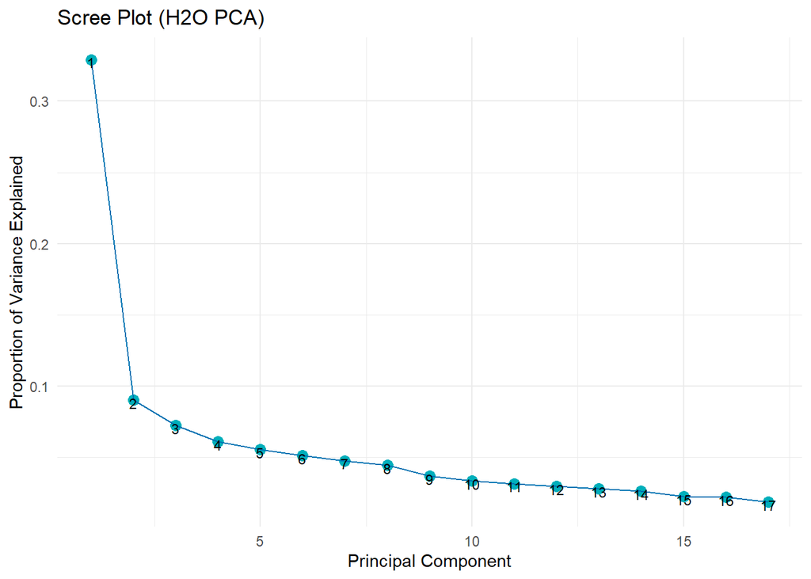

```r
# Extract importance matrix from pca_model
importance <- pca_model@model$importance

# Create a data frame for plotting
scree_df <- data.frame(
  PC = seq_along(importance[2, ]),
  PVE = as.numeric(importance[2, ])
)

# Plot

ggplot(scree_df, aes(x = PC, y = PVE, label = PC)) +
  geom_point(color = "#00AFBB", size = 3) +
  geom_line(group = 1, color = "#0072B2") +
  geom_text(nudge_y = -0.002, size = 3) +
  labs(title = "Scree Plot (H2O PCA)", x = "Principal Component", y = "Proportion of Variance Explained") +
  theme_minimal()
```

```r
# scale by z-score for preprocessing
df$z_weighted_risk <- scale(df$drug_composite_score)
head(df$z_weighted_risk)
```

```
##            [,1]
## [1,] -0.7387067
## [2,]  1.1300183
## [3,] -0.8699549
## [4,] -0.5824588
## [5,] -0.5949586
## [6,] -0.8824547
```

### Imputation for Missing Values

```r
### adapted from https://libguides.princeton.edu/R-Missingdata#:~:text=Imputation%20with%20Mean,-When%20dealing%20with&text=This%20method%2C%20known%20as%20%22mean,average%20for%20the%20missing%20entries.&text=Suitable%20for%20MCAR%3A%20Mean%20imputation,Completely%20At%20Random%20(MCAR).


# Loop through each column and apply imputation to numeric ones
for(i in seq_along(df)) {
  if(is.numeric(df[[i]])) {
    df[[i]][is.na(df[[i]])] <- median(df[[i]], na.rm = TRUE)
  }
}

# Check that all missing values are filled
sapply(df, function(x) sum(is.na(x)))
```

```
##                   id                  age               gender
##                    0                    0                    0
##            education              country            ethnicity
##                    0                    0                    0
##               nscore               escore               oscore
##                    0                    0                    0
##               ascore               cscore            impuslive
##                    0                    0                    0
##                   ss              alcohol               amphet
##                    0                    0                    0
##                 amyl               benzos                 caff
##                    0                    0                    0
##             cannabis                 choc                 coke
##                    0                    0                    0
##                crack              ecstasy               heroin
##                    0                    0                    0
##             ketamine               legalh                  lsd
##                    0                    0                    0
##                 meth            mushrooms             nicotine
##                    0                    0                    0
##                semer                  vsa           risk_score
##                   95                   86                    0
## drug_composite_score             pca_risk      z_weighted_risk
##                    0                    0                    0
```

#### Compare Imputation to Original Data

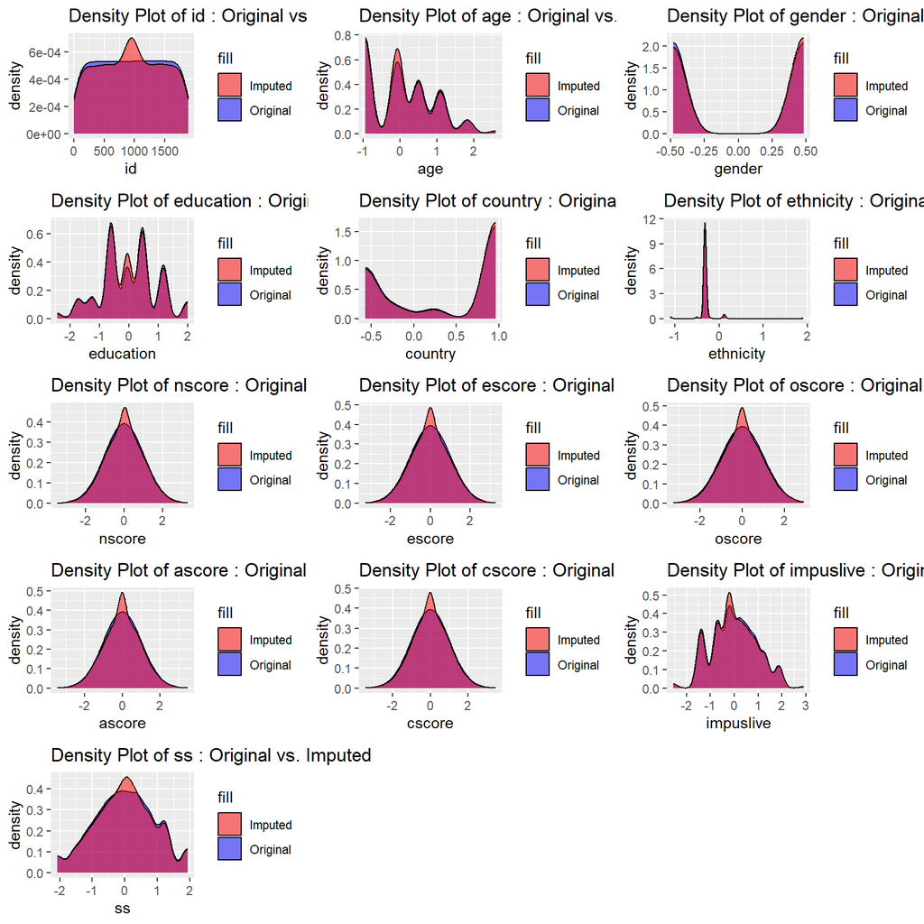

```r
# List of derived variables to exclude from the loop
derived_vars <- c("risk_score", "weighted_risk", "drug_composite_score", "pca_risk", "z_weighted_risk")

# Get numeric variable names
numeric_vars <- colnames(prime_df)

# Filter out derived variables
valid_vars <- numeric_vars[!(numeric_vars %in% derived_vars)]

# List to store plots
plot_list <- list()

# Loop through valid variables and create density plots
for(var in valid_vars) {
  # Check if the variable is numeric
  if(is.numeric(prime_df[[var]])) {
    p <- ggplot(prime_df, aes_string(x = var, fill = "\"Original\"")) +
      geom_density(alpha = 0.5) +
      geom_density(data = df, aes_string(x = var, fill = "\"Imputed\""), alpha = 0.5) +
      labs(title = paste("Density Plot of", var, ": Original vs. Imputed")) +
      scale_fill_manual(values = c("Original" = "blue", "Imputed" = "red"))

    # Store the plot in the list
    plot_list[[var]] <- p
  }
}

# Arrange all plots in a grid
grid.arrange(grobs = plot_list, ncol = 3)
```

### Normalization

The data is scaled before running analyses like PCA. The caret package is used to subtract the mean of each variable and divide by the standard deviation. The result is a dataset where all numeric variables have a mean = 0 and standard deviation = 1. This is important because it allows for all variables to contribute equally before the PCA finds components based on patterns.

```r
# preprocessing (scale data)
pre_proc <- preProcess(personality_vars_df, method = c("center", "scale"))
scaled_person_df <- predict(pre_proc, personality_vars_df)

head(scaled_person_df)
```

|  | nscore | escore | oscore | ascore | cscore |
| --- | --- | --- | --- | --- | --- |
| 1 | 0.3124260 | -0.5731889 | -0.58457541 | -0.9071759 | -0.007935311 |
| 2 | -0.6824428 | 1.9524823 | 1.44181398 | 0.7595201 | -0.145227258 |
| 3 | -0.4706447 | 0.8137299 | -0.84959892 | -1.6063648 | -1.024462557 |
| 4 | -0.1510103 | -0.8049313 | -0.01838014 | 0.5901239 | 0.588697647 |
| 5 | 0.7366043 | -1.6359193 | -0.45250032 | -0.2960325 | 1.316137193 |
| 6 | -0.6824428 | NA | -1.56020645 | 2.0297035 | 1.643693266 |

Here, I’ve chosen to inspect the effects on Min-Max Normalization before modeling.

```r
# Feature scaling (Min-Max normalization)
scale_minmax <- function(x) {
  return ((x - min(x, na.rm = TRUE)) / (max(x, na.rm = TRUE) - min(x, na.rm = TRUE)))
}

# Check for columns that are numeric, excluding "id"
numeric_vars <- setdiff(names(df)[sapply(df, is.numeric)], "id")

#numeric_cols <- sapply(df, is.numeric)  # Identify numeric columns
df_scaled <- df
df_scaled[, numeric_vars] <- lapply(df_scaled[, numeric_vars], scale_minmax)
head(df_scaled)
```

|  | id | age | gender | education | country | ethnicity | nscore | escore | oscore | ascore | cscore | impuslive | ss | alcohol | amphet | amyl | benzos | caff | cannabis | choc | coke | crack | ecstasy | heroin | ketamine | legalh | lsd | meth | mushrooms | … |
| --- | --- | --- | --- | --- | --- | --- | --- | --- | --- | --- | --- | --- | --- | --- | --- | --- | --- | --- | --- | --- | --- | --- | --- | --- | --- | --- | --- | --- | --- | --- |
| 1 | 1 | 0.4091368 | 1 | 0.5376809 | 1.000000 | 0.4090609 | 0.5605621 | 0.4121163 | 0.4356898 | 0.3676538 | 0.4990402 | 0.4284743 | 0.2243982 | 0.8333333 | 0.3333333 | 0.0000000 | 0.3333333 | 1.0000000 | 0.0000000 | 0.8333333 | 0.0000000 | 0 | 0.0000000 | 0 | 0.0000000 | 0.0000000 | 0.0000000 | 0.0 | 0.0000000 | … |
| 2 | 2 | 0.2464754 | 0 | 1.0000000 | 1.000000 | 0.2621431 | 0.4134743 | 0.7961059 | 0.7625665 | 0.6098269 | 0.4793945 | 0.3379202 | 0.4656581 | 0.8333333 | 0.3333333 | 0.3333333 | 0.0000000 | 1.0000000 | 0.6666667 | 0.8333333 | 0.5000000 | 0 | 0.6666667 | 0 | 0.3333333 | 0.0000000 | 0.3333333 | 0.5 | 0.0000000 | … |
| 3 | 3 | 0.4091368 | 0 | 0.5376809 | 1.000000 | 0.2621431 | 0.4447879 | 0.6229761 | 0.3929389 | 0.2660607 | 0.3535805 | 0.2154008 | 0.6199575 | 1.0000000 | 0.0000000 | 0.0000000 | 0.0000000 | 1.0000000 | 0.5000000 | 0.6666667 | 0.0000000 | 0 | 0.0000000 | 0 | 0.0000000 | 0.0000000 | 0.0000000 | 0.0 | 0.1666667 | … |
| 4 | 4 | 0.0000000 | 1 | 0.8143285 | 1.000000 | 0.2621431 | 0.4920447 | 0.3768834 | 0.5270227 | 0.5852134 | 0.5844153 | 0.2154008 | 0.2243982 | 0.6666667 | 0.0000000 | 0.0000000 | 0.5000000 | 0.8333333 | 0.3333333 | 0.6666667 | 0.3333333 | 0 | 0.0000000 | 0 | 0.3333333 | 0.0000000 | 0.0000000 | 0.0 | 0.0000000 | … |
| 5 | 948 | 0.4091368 | 1 | 1.0000000 | 1.000000 | 0.2621431 | 0.6232753 | 0.2505445 | 0.4569949 | 0.4564537 | 0.6885081 | 0.4284743 | 0.4656581 | 0.6666667 | 0.1666667 | 0.1666667 | 0.0000000 | 1.0000000 | 0.5000000 | 1.0000000 | 0.0000000 | 0 | 0.1666667 | 0 | 0.0000000 | 0.1666667 | 0.0000000 | 0.0 | 0.3333333 | … |
| 6 | 6 | 1.0000000 | 1 | 0.2733763 | 0.535185 | 0.2621431 | 0.4134743 | 0.5005070 | 0.2783109 | 0.7943863 | 0.7353797 | 0.2154008 | 0.1324680 | 0.3333333 | 0.0000000 | 0.0000000 | 0.0000000 | 1.0000000 | 0.0000000 | 0.6666667 | 0.0000000 | 0 | 0.0000000 | 0 | 0.0000000 | 0.0000000 | 0.0000000 | 0.0 | 0.0000000 | … |

## Modeling

### Unsupervised Learning

#### Principal Component Analysis

```r
# rerunning the PCA to feed ranked features to ensemble regression
pca_model <- h2o.prcomp(
  training_frame = drug_data_h2o,
  transform = "STANDARDIZE",
  k = length(drug_features),
  use_all_factor_levels = TRUE,
  impute_missing = TRUE
)
```

[output not shown]

```r
pca_components <- h2o.predict(pca_model, drug_data_h2o)
```

[output not shown]

```r
# Convert to R dataframe
pca_df <- as.data.frame(pca_components)
```

```r
# Bind PCA + target
final_df <- cbind(pca_df, z_weighted_risk = df$z_weighted_risk)
```

### Supervised Learning

#### Split Training and Test Data

```r
# Ensure the target variable is numeric
final_df$z_weighted_risk <- as.numeric(final_df$z_weighted_risk)

# Remove rows with missing values in the target or predictors
final_df <- na.omit(final_df)

# Set a seed for reproducibility
set.seed(123)

# Split the data into training+validation (90%) and test (10%)
trainValIndex <- createDataPartition(final_df$z_weighted_risk, p = 0.9, list = FALSE)
trainValData <- final_df[trainValIndex, ]
testData <- final_df[-trainValIndex, ]

# Split trainValData into training (80% of total) and validation (10% of total)
trainIndex <- createDataPartition(trainValData$z_weighted_risk, p = 8/9, list = FALSE)
trainData <- trainValData[trainIndex, ]
valData <- trainValData[-trainIndex, ]
```

#### Train Ensemble Models

I trained an ensemble (stacked model) with a Generalized Linear Model (GLM) meta-learner combining predictions from:

- Random Forest (`rf`)
- Gradient Boosting Machine (`gbm`)

This suggests GBM was far more predictive in this setup and dominates the ensemble’s decision-making.

##### Random Forest

Random Forest is an ensemble method that applies bagging to a collection of homogeneous learners — specifically, decision trees — to reduce variance and improve model stability.

```r
# Define the training control for 10-fold CV
train_control <- trainControl(method = "cv", number = 10, savePredictions = "all")

# Train a Random Forest model using trainData
rf_model <- train(
  z_weighted_risk ~ .,
  data = trainData,
  method = "rf",
  trControl = train_control
)

# Predict on the validation set
val_preds_rf <- predict(rf_model, newdata = valData)

# Compute RMSE on the validation set
val_rmse_rf <- sqrt(mean((val_preds_rf - valData$z_weighted_risk)^2))
print(paste("Validation RMSE (Random Forest):", round(val_rmse_rf, 4)))
```

```
## [1] "Validation RMSE (Random Forest): 0.1725"
```

The low Root Mean Squared Error (RMSE) indicates fairly high model performance from the random forest. This suggest high accuracy for predicting risk of drug usage on the unseen validation data.

##### Gradient Boosting

```r
# GBM model on trainData
gbm_model <- train(
  z_weighted_risk ~ .,
  data = trainData,
  method = "gbm",
  trControl = trainControl(method = "none"),
  verbose = FALSE
)

# Predict on validation data
val_preds <- predict(gbm_model, newdata = valData)

# RMSE on validation
gbm_val_rmse <- sqrt(mean((val_preds - valData$z_weighted_risk)^2))
print(paste("Validation RMSE:", round(gbm_val_rmse, 4)))
```

```
## [1] "Validation RMSE: 0.2717"
```

##### Stacked Ensemble

The stacked ensemble trains the two base models, random forest and GBM. Then meta-learning is implemented to combine predictions to minimize error.

```r
# Define training control
train_control <- trainControl(
  method = "cv",
  number = 10,
  savePredictions = "final",  # needed for stacking
  verboseIter = FALSE
)

# Train base models using caretList
set.seed(123)
base_models <- caretList(
  z_weighted_risk ~ .,
  data = trainData,
  trControl = train_control,
  methodList = c("rf", "gbm")
)
# Stack the models
set.seed(123)
ensemble_model <- caretStack(
  base_models,
  method = "glm",  # meta-model
  trControl = trainControl(method = "cv", number = 10)
)

# View results
summary(ensemble_model)
```

```
## The following models were ensembled: rf, gbm
##
## Model Importance:
##     rf    gbm
## 0.0097 0.9903
##
## Model accuracy:
##    model_name metric     value         sd
##        <char> <char>     <num>      <num>
## 1:   ensemble   RMSE 0.1175302 0.02043112
## 2:         rf   RMSE 0.1888831 0.03342762
## 3:        gbm   RMSE 0.1173730 0.01891278
```

```r
# make predictions
ensemble_preds <- predict(ensemble_model, newdata = valData)

# Extract the predictions from the 'pred' column
ensemble_preds <- ensemble_preds$pred

# Ensure the target variable 'z_weighted_risk' is numeric
valData$z_weighted_risk <- as.numeric(as.character(valData$z_weighted_risk))

# Calculate RMSE
ensemble_rmse <- sqrt(mean((ensemble_preds - valData$z_weighted_risk)^2))

# stacked
print(paste("Ensemble RMSE:", round(ensemble_rmse, 4)))
```

```
## [1] "Ensemble RMSE: 0.1368"
```

```r
# gbm
print(paste("Validation RMSE:", round(gbm_val_rmse, 4)))
```

```
## [1] "Validation RMSE: 0.2717"
```

```r
#rf
print(paste("Validation RMSE (Random Forest):", round(val_rmse_rf, 4)))
```

```
## [1] "Validation RMSE (Random Forest): 0.1725"
```

The ensemble model, combining Random Forest (RF) and Gradient Boosting Machine (GBM), achieved a validation RMSE of 0.1368, which is lower than the individual performance of both models.This suggests that the ensemble model, which leverages the strengths of both RF and GBM, outperforms each model on its own, providing better predictive accuracy as indicated by the lower RMSE.

The summary of the stacked ensemble shows that GBM model has a much higher importance than random forest.

## Evaluation

### Test Data Predictions

Next, I make predictions using the test data.

```r
# Make predictions using the ensemble model
predictions <- predict(ensemble_model, newdata = testData)

# Evaluate model performance (e.g., using RMSE, R-squared)
postResample(predictions, testData$z_weighted_risk)
```

```
##       RMSE   Rsquared        MAE
## 0.10245513 0.99083034 0.06872129
```

- The **Root Mean Squared Error (RMSE)** is fairly low at 0.1025, indicating higher accuracy.
- The **R-squared** is quite high at 0.9908, meaning that nearly all of the variance in the target variable is explained by the model.
- The **Mean Absolute Error** is low at 0.0687, meaning that there is a small but acceptable amount of error in the predictions.

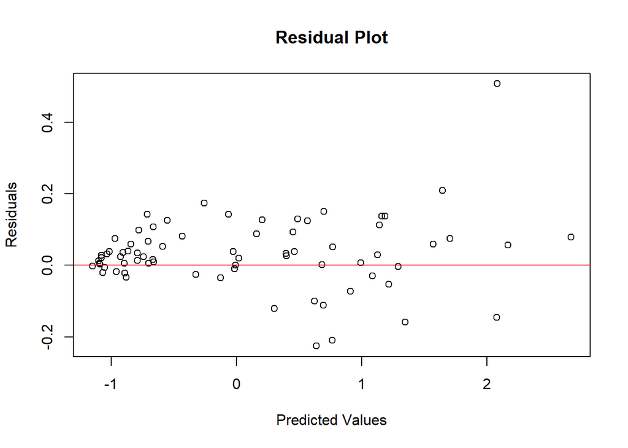

```r
# Ensure predictions are a numeric vector (if they are not already)
predictions_numeric <- as.numeric(predictions$pred)  # or adjust if `predictions` is a data.table

# Calculate residuals
residuals <- testData$z_weighted_risk - predictions_numeric

# Plot residuals
plot(predictions_numeric, residuals,
     main="Residual Plot",
     xlab="Predicted Values",
     ylab="Residuals")
abline(h=0, col="red")  # Add a horizontal line at 0 for reference
```

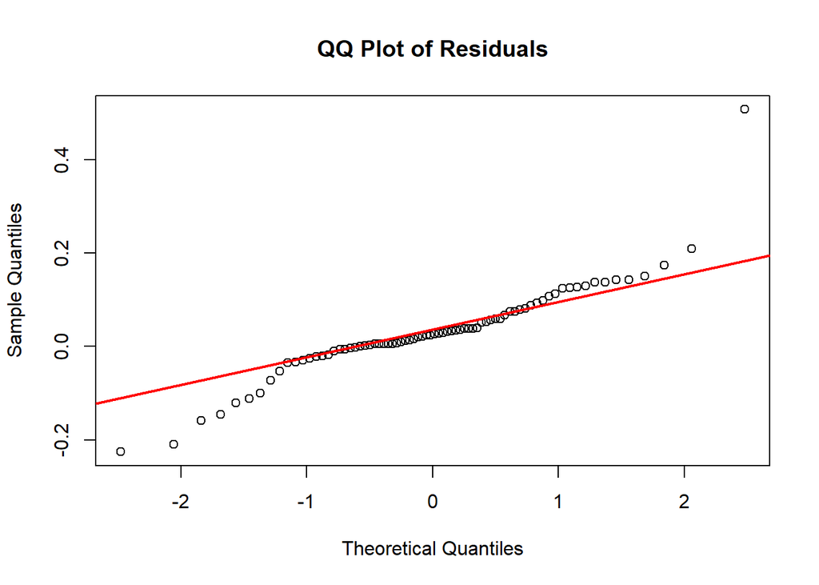

```r
# Calculate residuals
residuals <- testData$z_weighted_risk - predictions_numeric

# Now, plot the QQ plot
qqnorm(residuals, main = "QQ Plot of Residuals")
qqline(residuals, col = "red", lwd = 2)  # Red line for normality reference
```

## Deployment

This program should be carefully evaluated for bias and ethical considerations, particularly those related to demographic, socioeconomic, or clinical factors, before deployment.

If validated, this model may be deployed as a decision-support tool for healthcare institutions aiming to proactively identify individuals at risk of severe drug use. The model’s outputs could assist clinicians, case managers, or public health officials in tailoring early interventions, allocating resources, or prioritizing care.

### Opportunities for Improvement

- **Validate Assumptions**: The current model uses the recency or severity of drug usage as an indicator of risk. A literature and real-world informed method for encoding risk of drug usage should be refined.
- **Expand Training Data**: Incorporating more diverse and recent datasets—especially those reflecting underrepresented populations considering the skews present in the data—could improve generalizability and reduce bias.
- **Model Tuning**: Hyperparameter optimization and testing alternative model architectures (e.g., ensemble methods, neural networks) may yield better performance.
- **Evaluating Bias**: Models that can handle protected class status for reducing biases may be helpful for improvement; such as the fairlearn in Python.